# R handout: Computer exercises lecture 6

Maarten Speekenbrink

15 November 2016

## Factors

R has a special type of object for categorical variables, called `factor`. A `factor` is an integer valued variable with labels attached to each integer value.

```r
library(foreign)
dat <- as.data.frame(read.spss("2016_Questionnaire_1_cleaned.sav"))
# what type of object is this?
is(dat$Gender)
```

```
## [1] "factor"              "integer"             "oldClass"
## [4] "numeric"             "vector"              "data.frameRowLabels"
```

```r
# summary
summary(dat$Gender)
```

```
## Female Male
##     90     50
```

```r
# print the levels of the factor (i.e., the labels)
levels(dat$Gender)
```

```
## [1] "Female" "Male  "
```

```r
## Annoyingly the Male label has some additional spaces, so let's get rid of those
levels(dat$Gender) <- c("Female","Male")
levels(dat$Gender) # did that work?
```

```
## [1] "Female" "Male"
```

If there is a variable which isn’t a factor, but you’d like to use as such (e.g., `reptn` in the `LearnMemory.sav` data), you can use the `as.factor` function. For instance:

```r
learnMem <- as.data.frame(read.spss("LearnMemory.sav"))
summary(learnMem)
```

```
##        other        reptn        recall
##  numbers  :18   Min.   : 4   Min.   : 4.00
##  syllables:18   1st Qu.: 4   1st Qu.: 9.75
##                 Median : 8   Median :12.00
##                 Mean   : 8   Mean   :11.67
##                 3rd Qu.:12   3rd Qu.:14.25
##                 Max.   :12   Max.   :16.00
```

```r
learnMem$reptn <- as.factor(learnMem$reptn)
summary(learnMem)
```

```
##        other    reptn       recall
##  numbers  :18   4 :12   Min.   : 4.00
##  syllables:18   8 :12   1st Qu.: 9.75
##                 12:12   Median :12.00
##                         Mean   :11.67
##                         3rd Qu.:14.25
##                         Max.   :16.00
```

## Contrasts

Factors have automatically associated to them a contrast code. There are four built-in contrasts available in R:

### `contr.treatment`

`contr.treatment` provides dummy coding, using the first level of the factor as reference group. Usage: `contr.treatment(m)` where `m` is the number of groups, e.g.

```r
contr.treatment(4)
```

```
##   2 3 4
## 1 0 0 0
## 2 1 0 0
## 3 0 1 0
## 4 0 0 1
```

Note that the columns in this output are the contrast variables, and the rows the different groups!

```r
## Instead of the number of groups, you can also use a vector with labels to create the codes:
contr.treatment(c("A","B","C","D"))
```

```
##   B C D
## A 0 0 0
## B 1 0 0
## C 0 1 0
## D 0 0 1
```

### `contr.sum`

`contr.sum` provides effect coding, which is like dummy coding but using a -1 instead of a 0 for the “reference group”. As a result, the intercept now represents the “grand mean”.

```r
contr.sum(c("A","B","C","D"))
```

```
##   [,1] [,2] [,3]
## A    1    0    0
## B    0    1    0
## C    0    0    1
## D   -1   -1   -1
```

### `contr.helmert`

Helmert coding is obtained with `contr.helmert`, where R uses a different ordering than in the lecture (the last contrast code compares the last level to the earlier ones, the second-last level compares the second-last level to the earlier ones, etc).

```r
contr.helmert(c("A","B","C","D"))
```

```
##   [,1] [,2] [,3]
## A   -1   -1   -1
## B    1   -1   -1
## C    0    2   -1
## D    0    0    3
```

### `contr.poly`

Polynomial contrasts are obtained with `contr.poly`, where R doesn’t use whole numbers like is often done in tables with example contrasts.

```r
contr.poly(c("A","B","C","D"))
```

```
##              .L   .Q         .C
## [1,] -0.6708204  0.5 -0.2236068
## [2,] -0.2236068 -0.5  0.6708204
## [3,]  0.2236068 -0.5 -0.6708204
## [4,]  0.6708204  0.5  0.2236068
```

### Default contrasts

You can see which of these R uses by default with the options function:

```r
options()$contrasts
```

```
##         unordered           ordered
## "contr.treatment"      "contr.poly"
```

which also allows you to set the default contrasts. So for instance, you can tell R to use orthogonal contrasts (rather than dummy coding) by default as follows:

```r
options(contrasts = c("contr.helmert","contr.poly"))
contrasts(dat$Gender)
```

```
##        [,1]
## Female   -1
## Male      1
```

Note that there are different defaults for ordered and unordered factors. As the name implies, ordered factors have levels which can be meaningfully ordered. For instance, `Self_esteem` is such a variable.

```r
levels(dat$Self_esteem)
```

```
## [1] "High     " "Low      " "Moderate " "Very high" "Very Low "
```

```r
## again there are some irritating spaces which we'll first get rid off
levels(dat$Self_esteem) <- c("High","Low","Moderate","Very high","Very low")
summary(dat$Self_esteem)
```

```
##      High       Low  Moderate Very high  Very low
##        41        18        70        10         1
```

```r
contrasts(dat$Self_esteem) # this should be a Helmert contrast code
```

```
##           [,1] [,2] [,3] [,4]
## High        -1   -1   -1   -1
## Low          1   -1   -1   -1
## Moderate     0    2   -1   -1
## Very high    0    0    3   -1
## Very low     0    0    0    4
```

```r
## also note that R has ordered the levels alphabetically, we can change this ordering
# as follows:
dat$Self_esteem <- factor(dat$Self_esteem,levels=c("Very low","Low","Moderate","High","Very high"))
summary(dat$Self_esteem) # check that we didn't mess up the variable
```

```
##  Very low       Low  Moderate      High Very high
##         1        18        70        41        10
```

```r
## we can also change it to an ordered factor
dat$Self_esteem <- ordered(dat$Self_esteem)
levels(dat$Self_esteem)
```

```
## [1] "Very low"  "Low"       "Moderate"  "High"      "Very high"
```

```r
contrasts(dat$Self_esteem) # this should be a polynomial contrast code
```

```
##              .L         .Q            .C         ^4
## [1,] -0.6324555  0.5345225 -3.162278e-01  0.1195229
## [2,] -0.3162278 -0.2672612  6.324555e-01 -0.4780914
## [3,]  0.0000000 -0.5345225 -4.095972e-16  0.7171372
## [4,]  0.3162278 -0.2672612 -6.324555e-01 -0.4780914
## [5,]  0.6324555  0.5345225  3.162278e-01  0.1195229
```

## Using factors in linear models

If you include a `factor` as a predictor in a linear model, R will automatically replace the factor with the associated contrasts coded predictors. For instance, we can try to predict people’s reported random numbers in the questionnary by their reported self esteem as follows:

```r
mod <- lm(lm(RandomNumber~Self_esteem,data=dat))
summary(mod)
```

```
##
## Call:
## lm(formula = lm(RandomNumber ~ Self_esteem, data = dat))
##
## Residuals:
##     Min      1Q  Median      3Q     Max
## -5.3415 -1.5362  0.2222  1.7063  4.4638
##
## Coefficients:
##               Estimate Std. Error t value Pr(>|t|)
## (Intercept)     5.3422     0.5427   9.844   <2e-16 ***
## Self_esteem.L   1.6364     1.6622   0.984    0.327
## Self_esteem.Q  -1.7587     1.4138  -1.244    0.216
## Self_esteem.C   0.7679     0.9348   0.821    0.413
## Self_esteem^4  -1.0403     0.5040  -2.064    0.041 *
## ---
## Signif. codes:  0 '***' 0.001 '**' 0.01 '*' 0.05 '.' 0.1 ' ' 1
##
## Residual standard error: 2.471 on 133 degrees of freedom
##   (2 observations deleted due to missingness)
## Multiple R-squared:  0.03435,    Adjusted R-squared:  0.005305
## F-statistic: 1.183 on 4 and 133 DF,  p-value: 0.3214
```

```r
## we can also first explicitly ask for e.g. a Helmert contrast for a vavriabke
contrasts(dat$Self_esteem) <- contr.helmert(5)
summary(lm(lm(RandomNumber~Self_esteem,data=dat)))
```

```
##
## Call:
## lm(formula = lm(RandomNumber ~ Self_esteem, data = dat))
##
## Residuals:
##     Min      1Q  Median      3Q     Max
## -5.3415 -1.5362  0.2222  1.7063  4.4638
##
## Coefficients:
##              Estimate Std. Error t value Pr(>|t|)
## (Intercept)   5.34221    0.54266   9.844   <2e-16 ***
## Self_esteem1  1.63889    1.26946   1.291    0.199
## Self_esteem2  0.29911    0.43462   0.688    0.493
## Self_esteem3  0.35087    0.23386   1.500    0.136
## Self_esteem4  0.05334    0.20941   0.255    0.799
## ---
## Signif. codes:  0 '***' 0.001 '**' 0.01 '*' 0.05 '.' 0.1 ' ' 1
##
## Residual standard error: 2.471 on 133 degrees of freedom
##   (2 observations deleted due to missingness)
## Multiple R-squared:  0.03435,    Adjusted R-squared:  0.005305
## F-statistic: 1.183 on 4 and 133 DF,  p-value: 0.3214
```

While making use of the default contrasts for factor can be handy, sometimes it is easier to get exactly the results you want by creating new contrast coded predictors yourself. Another option is to supply a matrix with the contrast codes yourself when assigning the contrast for a factor. For instance:

```r
myPoly <- cbind(L = c(-2,-1,0,1,2),
                Q = c(2,-1,-2,-1,2),
                C = c(-1,2,0,-2,1),
                "^4"=c(1,-4,6,-4,1))
myPoly
```

```
##       L  Q  C ^4
## [1,] -2  2 -1  1
## [2,] -1 -1  2 -4
## [3,]  0 -2  0  6
## [4,]  1 -1 -2 -4
## [5,]  2  2  1  1
```

```r
contrasts(dat$Self_esteem) <- myPoly
summary(lm(RandomNumber~Self_esteem,data=dat))
```

```
##
## Call:
## lm(formula = RandomNumber ~ Self_esteem, data = dat)
##
## Residuals:
##     Min      1Q  Median      3Q     Max
## -5.3415 -1.5362  0.2222  1.7063  4.4638
##
## Coefficients:
##               Estimate Std. Error t value Pr(>|t|)
## (Intercept)    5.34221    0.54266   9.844   <2e-16 ***
## Self_esteemL   0.51748    0.52564   0.984    0.327
## Self_esteemQ  -0.47004    0.37786  -1.244    0.216
## Self_esteemC   0.24282    0.29561   0.821    0.413
## Self_esteem^4 -0.12434    0.06024  -2.064    0.041 *
## ---
## Signif. codes:  0 '***' 0.001 '**' 0.01 '*' 0.05 '.' 0.1 ' ' 1
##
## Residual standard error: 2.471 on 133 degrees of freedom
##   (2 observations deleted due to missingness)
## Multiple R-squared:  0.03435,    Adjusted R-squared:  0.005305
## F-statistic: 1.183 on 4 and 133 DF,  p-value: 0.3214
```

## Creating your own contrast coded predictors

To create your own contrast coded predictors, you can first create a new variable and then set the values by using indexing. For instance, you can create a dummy-coded predictor for `Gender`, with females as the reference group, as follows:

```r
dat$dummy <- NA # create a new variable with only missing values
dat$dummy[dat$Gender == "Male"] <- 1
dat$dummy[dat$Gender == "Female"] <- 0
```

You can then use this newly created variable in the `lm` function as usual…

## Oneway ANOVA

Instead of using the `lm` function, you can also perform an ANalysis Of VAriance (ANOVA) by using the `aov` function. This function uses a formula argument, just like the `lm` function. However, it provides different tests as you will see in the summary. For instance, continuing our (silly!) example with `Self_esteem` and `RandomNumber`, you can test for differences in `RandomNumber` between the levels of `Self_esteem` as follows:

```r
aovmod <- aov(RandomNumber~Self_esteem,data=dat)
summary(aovmod)
```

```
##              Df Sum Sq Mean Sq F value Pr(>F)
## Self_esteem   4   28.9   7.222   1.183  0.321
## Residuals   133  812.2   6.107
## 2 observations deleted due to missingness
```

Note that by default R provides omnibus tests only for such an ANOVA model. You can ask for tests of the individual contrasts as well through the `split` argument. This requires you to know the names of the different contrasts, and the option is not documented overly well. I’m just going to provide you with an example here. If you want to use this option, play around with it a bit more…

```r
summary(aovmod,split=list(Self_esteem = list(L=1,Q=2,C=3,"^4"=4)))
```

```
##                    Df Sum Sq Mean Sq F value Pr(>F)
## Self_esteem         4   28.9   7.222   1.183  0.321
##   Self_esteem: L    1    1.8   1.820   0.298  0.586
##   Self_esteem: Q    1    0.1   0.091   0.015  0.903
##   Self_esteem: C    1    1.0   0.962   0.158  0.692
##   Self_esteem: ^4   1   26.0  26.017   4.260  0.041 *
## Residuals         133  812.2   6.107
## ---
## Signif. codes:  0 '***' 0.001 '**' 0.01 '*' 0.05 '.' 0.1 ' ' 1
## 2 observations deleted due to missingness
```

I have usually found it easier to specify my own contrast coded predictors to get output like this…

## Levene test for equality of variance

SPSS by default always provides the results of the Levene test for equality of variances (i.e., a test whether the assumption of homoscedasticity holds). You can obtain these test results through the `leveneTest` function in the `car` package:

```r
library(car)
leveneTest(aovmod,center=mean)
```

```
## Levene's Test for Homogeneity of Variance (center = mean)
##        Df F value Pr(>F)
## group   4    0.87 0.4838
##       133
```

## Post-hoc tests

In the exercises, we will mainly use the Tukey HSD tests. These can be obtained by calling the `TukeyHSD` function on a model fitted by the `aov` function, e.g.

```r
TukeyHSD(aovmod)
```

```
##   Tukey multiple comparisons of means
##     95% family-wise confidence level
##
## Fit: aov(formula = RandomNumber ~ Self_esteem, data = dat)
##
## $Self_esteem
##                           diff        lwr       upr     p adj
## Low-Very low        3.27777778 -3.7437626 10.299318 0.6971977
## Moderate-Very low   2.53623188 -4.3473792  9.419843 0.8462478
## High-Very low       3.34146341 -3.5756447 10.258572 0.6693258
## Very high-Very low  2.55555556 -4.6483928  9.759504 0.8633805
## Moderate-Low       -0.74154589 -2.5503464  1.067255 0.7883515
## High-Low            0.06368564 -1.8686816  1.996053 0.9999842
## Very high-Low      -0.72222222 -3.5122994  2.067855 0.9525422
## High-Moderate       0.80523153 -0.5424017  2.152865 0.4669209
## Very high-Moderate  0.01932367 -2.4027835  2.441431 0.9999999
## Very high-High     -0.78590786 -3.3016358  1.729820 0.9095053
```

There are other ways to perform post-hoc tests (e.g., Bonferroni or Scheffe corrections). Unfortunately, there are no easy automated functions to perform all these tests. If you need to run post-hoc tests for your own research, have a look at the `multcomp` package, which has a lot of functionality (but is too complicated to discuss here).

## factorial ANOVA

```r
library(car)
aovmod <- aov(RandomNumber~Self_esteem*Gender,data=dat)
Anova(aovmod,type=3,singular.ok=TRUE)
```

```
## Anova Table (Type III tests)
##
## Response: RandomNumber
##                    Sum Sq  Df F value    Pr(>F)
## (Intercept)        231.65   1 37.7357 9.332e-09 ***
## Self_esteem         17.78   4  0.7242    0.5770
## Gender               1.32   1  0.2149    0.6437
## Self_esteem:Gender  19.06   3  1.0351    0.3794
## Residuals          791.90 129
## ---
## Signif. codes:  0 '***' 0.001 '**' 0.01 '*' 0.05 '.' 0.1 ' ' 1
```

Note that I had to set the `singular.ok` argument to `TRUE` for this example as the data is extremely unbalanced (the “Very low”" self esteem group contains just one person…). Normally, you should not have to specify this argument, and e.g.

```r
Anova(aovmod,type=3)
```

should be enough.

### interaction plots

Plots can be useful to interpret interaction effects. For a quick (although not overly pretty) look, you can use the `interaction.plot` function, with the syntax `interaction.plot(x.factor, trace.factor, response, ...)` where the `x.factor` is the factor you want on the x-axis, the `trace.factor` is a factor for which you want to plot a different line for each level, and `response` is the dependent variable. For example:

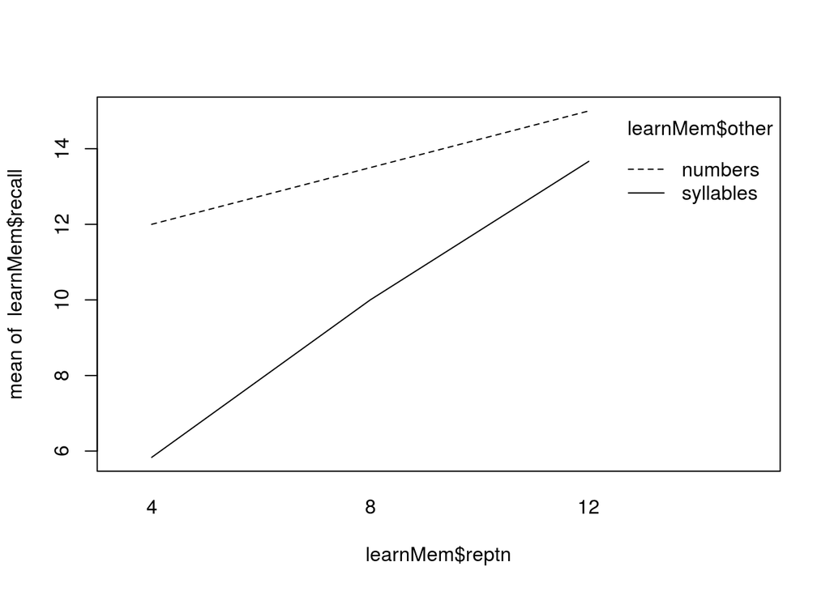

```r
interaction.plot(x.factor=learnMem$reptn,trace.factor=learnMem$other,response=learnMem$recall)
```